# The Monty Hall problem for sceptics

Joan Marine-Boada

### The Problem

The [Monty Hall problem](https://en.wikipedia.org/wiki/Monty_Hall_problem) is named for its similarity to the *Let’s Make a Deal* television game show hosted by *Monty Hall*. The problem is stated as follows. Assume that a room is equipped with three doors, A, B and C. Behind two are goats, and behind the third is a shiny new car. You are asked to pick a door, and will win whatever is behind it. Let’s say you pick door A. Before the door is opened, however, someone who knows what’s behind the doors (Monty Hall) opens one of the other two doors, revealing a goat, and asks you if you wish to change your selection to the third door (i.e., the door which neither you picked nor he opened). The Monty Hall problem is deciding whether you do.

### The Solution

The correct answer is that you do want to switch. If you do not switch, you have the expected $1/3$ chance of winning the car, since no matter whether you initially picked the correct door, Monty Hall will show you a door with a goat. But after Monty has eliminated one of the doors for you, you obviously do not improve your chances of winning to better than $1/3$ by sticking with your original choice. If you now switch doors, however, there is a $2/3$ chance you will win the car (counterintuitive though it seems).

Let’s write it with some mathematical rigour:

We have the three doors: $A$, $B$ and $C$. And our choice is, for instance, the door $A$. Now we define the following events:

- $C_A$ := the car is behind the door $A$.
- $C_B$ := the car is behind the door $B$.
- $C_C$ := the car is behind the door $C$.

Since we suppose that this is a fair game, we must assume that:

$$P(C_A) = P(C_B) = P(C_C) = 1/3$$
Now we define the event that we want to know its probability:

- $WIC$ := winning the game if we decide to change the door.

Of course, due to we have chosen the door $A$, if the car is behind the doors $B$ or $C$ it is sure we gonna win if we decide to change our election. On the contrary, if the car is behind the door A, we gonna lose for sure in case we change the door. So,

- $P(WIC | C_A) = 0$
- $P(WIC | C_B) = 1$
- $P(WIC | C_C) = 1$

Finally, solving the problem is easy using the [Law of Total Probability](https://en.wikipedia.org/wiki/Law_of_total_probability):

$$\begin{align}
P(WIC) &= P(WIC | C_A) \cdot P(C_A) + P(WIC | C_B) \cdot P(C_B) +
P(WIC | C_C) \cdot P(C_C)=\\
&= 0 \cdot 1/3 + 1 \cdot 1/3 + 1 \cdot 1/3 =\\
&= 2/3
\end{align}$$

### The Simulation

In order to convince those who don’t believe the solution, let’s to simulate the game one million times. In all of them we are going to always decide to change the door. Let’s count how many times we win the game.

```r
n <- 1000000

cars_door <- sample(c("A","B","C"), size = n, replace = T)

df <- data.frame(Cars_door = cars_door)

head(df)
```

|  | Cars_door |
| --- | --- |
| 1 | C |
| 2 | C |
| 3 | B |
| 4 | A |
| 5 | B |
| 6 | A |

We have created a dataframe with a million rows and a single column. The rows represent the times we play and in the column we have randomly set which door the car is at. Let’s to see if the car is distributed as we hope:

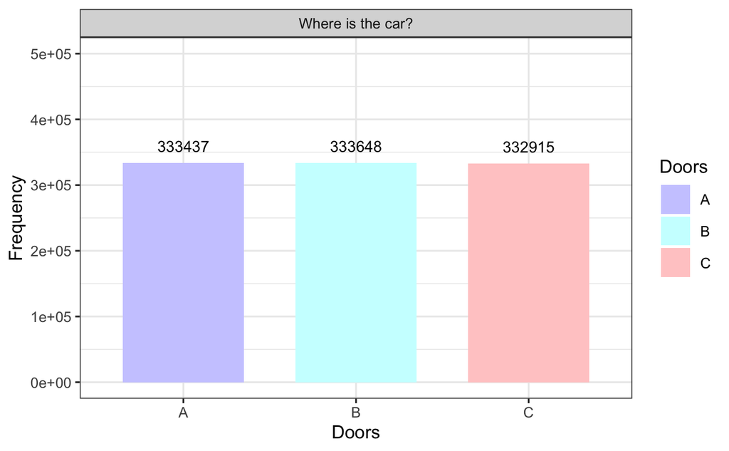

```r
library(ggplot2)

g <- ggplot(df, aes(x = factor(cars_door), fill = cars_door)) +
    geom_bar(width = 0.7, stat = "count") +
    labs(x = "Doors", y = "Frequency") +
    ylim(c(0,floor(n/3) * 1.5)) +
    theme_bw(base_size = 10) +
    geom_text(aes(label=..count..),
              stat = 'count',
              position = position_dodge(0.9),
              vjust = -1,
              size = 3.0) +
    facet_grid(~"Where is the car?") +
    guides(fill = guide_legend( title = "Doors")) +
    scale_fill_manual(values = c("A" = "#CCCCFF",
                                "B" = "#CCFFFF",
                                "C" = "#FFCCCC"))

print(g)
```

As expected, the car is distributed with the same proportion in each of the doors.

Now let’s define a new column of the dataframe that will correspond to the player’s choice. We are going to set it also randomly.

```r
df$Chosen_door <- sample(c("A","B","C"), size = n, replace = T)

head(df)
```

|  | Cars_door | Chosen_door |
| --- | --- | --- |
| 1 | C | C |
| 2 | C | B |
| 3 | B | C |
| 4 | A | B |
| 5 | B | A |
| 6 | A | A |

At this moment, we are already in a position to know how many times we win the car in the case of not changing the door when the host offers it to us.

```r
result_function <- function(CarsDoor, OpenedDoor){
     if(CarsDoor == OpenedDoor) {return ("Win")}
     else {return("Lose")}
}

df$Result_if_NO_change <- mapply(result_function, df$Cars_door, df$Chosen_door)

head(df)
```

|  | Cars_door | Chosen_door | Result_if_NO_change |
| --- | --- | --- | --- |
| 1 | C | C | Win |
| 2 | C | B | Lose |
| 3 | B | C | Lose |
| 4 | A | B | Lose |
| 5 | B | A | Lose |
| 6 | A | A | Win |

Remember that the probability of winning in case of avoiding the change is 1/3. In the million simulated cases, what proportion is a winning decision?

```r
sum(df['Result_if_NO_change'] == "Win") / n
```

```
[1] 0.332625
```

The next step will be to establish which door the host is going to open, depending on where the car is and the door that we have chosen. Let’s define a new column of our dataframe:

```r
hosts_door_function <- function(cars_door, chosen_door){

    aux <- c("A", "B", "C")
    i <- which(aux %in% cars_door)
    j <- which(aux %in% chosen_door)

    if(cars_door == chosen_door){
        var1 <- aux[(((i %% 3) + 1) %% 3) +1]
        var2 <- aux[(i %% 3) + 1]

        return(paste(var1,"or", var2)) # The host can choose the door between two
    }
    else{
        if(j == (i %% 3) + 1){return(aux[(j %% 3) + 1])}
        else{return(aux[(i %% 3) + 1])}
    }
}

df$Hosts_door <- mapply(hosts_door_function, df$Cars_door, df$Chosen_door)

head(df)
```

|  | Cars_door | Chosen_door | Result_if_NO_change | Hosts_door |
| --- | --- | --- | --- | --- |
| 1 | C | C | Win | B or A |
| 2 | C | B | Lose | A |
| 3 | B | C | Lose | A |
| 4 | A | B | Lose | C |
| 5 | B | A | Lose | C |
| 6 | A | A | Win | C or B |

Once we already know the door the host has opened, we will determine which door we will open when we change the decision:

```r
door_I_open_function <- function(hosts_door, chosen_door){

    if(hosts_door == "A or C"){return("C or A")}
    if(hosts_door == "B or A"){return("A or B")}
    if(hosts_door == "C or B"){return("B or C")}

    aux <- c("A", "B", "C")
    i <- which(aux %in% hosts_door)
    j <- which(aux %in% chosen_door)
    if(j == (i %% 3) + 1){return(aux[(j %% 3) + 1])}
    else{return(aux[(i %% 3) + 1])}
}

df$Door_I_open <- mapply(door_I_open_function, df$Hosts_door, df$Chosen_door)

head(df)
```

|  | Cars_door | Chosen_door | Result_if_NO_change | Hosts_door | Door_I_open |
| --- | --- | --- | --- | --- | --- |
| 1 | C | C | Win | B or A | A or B |
| 2 | C | B | Lose | A | C |
| 3 | B | C | Lose | A | B |
| 4 | A | B | Lose | C | A |
| 5 | B | A | Lose | C | B |
| 6 | A | A | Win | C or B | B or C |

The moment of truth is coming, now we can know if we win or lose each time we play the game:

```r
df$Result_if_change <- mapply(result_function, df$Cars_door, df$Door_I_open)

head(df)
```

|  | Cars_door | Chosen_door | Result_if_NO_change | Hosts_door | Door_I_open | Result_if_change |
| --- | --- | --- | --- | --- | --- | --- |
| 1 | C | C | Win | B or A | A or B | Lose |
| 2 | C | B | Lose | A | C | Win |
| 3 | B | C | Lose | A | B | Win |
| 4 | A | B | Lose | C | A | Win |
| 5 | B | A | Lose | C | B | Win |
| 6 | A | A | Win | C or B | B or C | Lose |

Finally we are going to count how many times we win the game when we change doors. This result divided by the times we play should be very close to $2/3$, the probability that we have previously calculated.

```r
sum(df['Result_if_change'] == "Win") / n
```

```
[1] 0.667375
```